# presentation

## Co nám statistický test dovoluje tvrdit?

Biostatistika

[👤](https://ondrejmottl.github.io/) Ondřej Mottl

[Moodle](https://dl2.cuni.cz/course/view.php?id=106)

## Měsíc je celý ze sýra

„Měsíc je celý ze sýra.“

Co by toto tvrzení mohlo změnit?

Je tvrzení **testovatelné**? Je také **věrohodné**?

Když nehlasujeme: napište jedno pozorování, které by mluvilo pro tvrzení, a jedno proti němu.

## Výsledky učení

Po dnešní přednášce budete schopni:

- popsat velikost efektu v jednotkách a jeho biologický význam
- spojit odhad, standardní chybu, t-statistiku a stupně volnosti
- interpretovat p-hodnotu podmíněně, ne jako pravděpodobnost pravdy
- rozlišit chybu I. a II. druhu a intuitivně vysvětlit sílu testu
- napsat opatrný vědecký závěr, který nekončí p-hodnotou

## Co může věda opravdu testovat?

Pozorování může rozhodnout?

1. Všechny labutě jsou bílé.
2. Holub stěhovavý vyhynul.

Pozorování může rozhodnout?

3. Měsíc je celý ze sýra.
4. Tento pták je nejkrásnější.

Ve dvojici: u každé věty určete, zda je empiricky testovatelná, a pojmenujte pozorování, které by změnilo váš závěr.

## Testovatelné neznamená pravdivé

Pozorování mohou závěr změnit

- ne-bílá labuť vyvrátí univerzální tvrzení;
- živý holub stěhovavý změní závěr o vyhynutí;
- měsíční hornina bez vlastností sýra mluví proti sýrovému Měsíci;
- „nejkrásnější“ je bez předem daného měřitelného kritéria hodnotový soud, ne stejný druh empirického tvrzení.

Co zůstává složitější

- měření může být nepřesné;
- hledání může něco přehlédnout;
- model má předpoklady;
- další studie mohou závěr upravit.

Statistický test má užší úkol

Hodnotí data v jednom přesně popsaném hypotetickém světě. **Nerozhoduje pravdu.**

## Jsou krabi na severu větší?

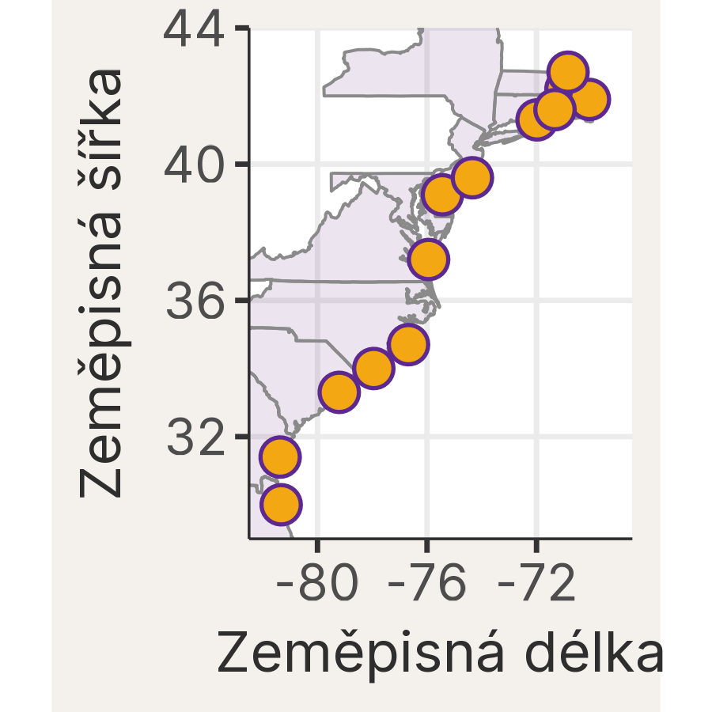

Atlantické pobřeží USA

- léto 2016;
- 13 slanisek od Floridy po Massachusetts;
- 392 dospělých samců kraba houslisty *Minuca pugnax*;
- šířka krunýře v milimetrech.

Hlavní otázka

Jak se průměrná velikost mění směrem na sever?

Data: [LTER `pie_crab`](https://lter.github.io/lterdatasampler/articles/pie_crab_vignette.html), CC0; souřadnice: [Johnson et al. 2019](https://doi.org/10.1002/ece3.5883).

## Co je jedna jednotka pozorování?

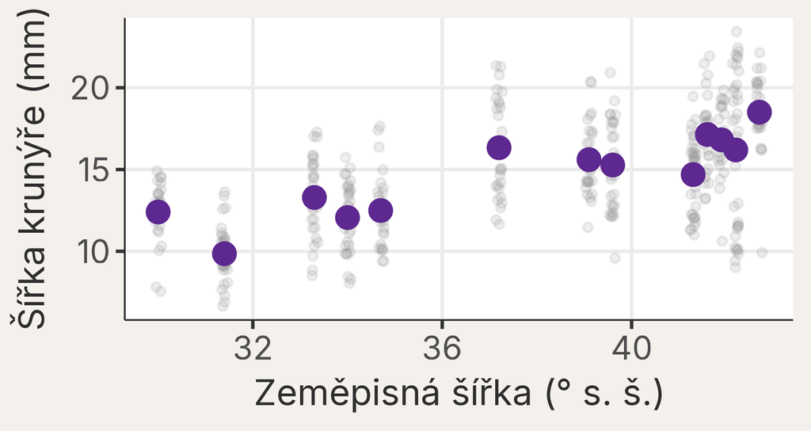

Hlasujte: hlavní analýza zeměpisné šířky má **392 krabů**, nebo **13 průměrů slanisek**? Když nehlasujeme, napište jednotku pozorování a jednu větu proč.

## Proč pracujeme se 13 průměry

Jednotliví krabi

Krabi ze stejného slaniska sdílejí zeměpisnou šířku i mnoho místních podmínek.

Hlavní důkaz

Jeden bod = průměr jednoho slaniska.

**n = 13 lokalit**

Co tím neřešíme

Průměrování není hierarchický ani prostorový model. Jen zabraňuje tomu, abychom 392 krabů vydávali za 392 nezávislých zeměpisných replikací.

## Jaký vzor čekáte?

Na ose x bude zeměpisná šířka.

Na ose y bude průměrná šířka krunýře.

Jak by vypadalo 13 bodů, kdyby byli krabi na severu větší?

Načrtněte si směr oblaku bodů. Výsledek zatím nevidíte.

## Třináct slanisek v jednom grafu

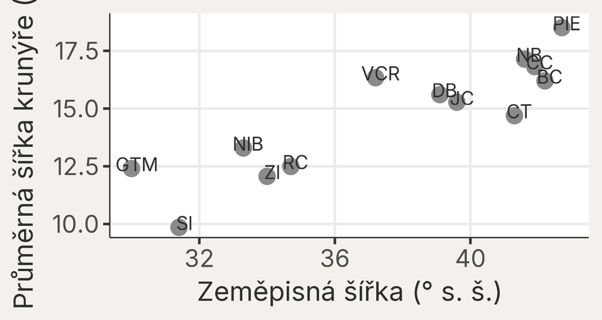

Popište pouze to, co vidíte: směr, rozptyl bodů a případně neobvyklé lokality.

## Přímka shrne velikost vztahu

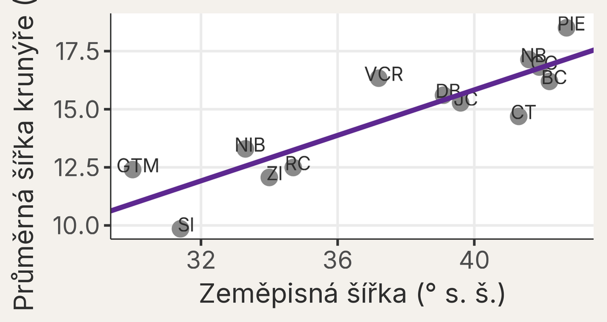

Sklon přímky je **0.49 mm na 1° severněji**.

## Známý model v R

```r
prumery_lokalit <-
  read.csv(
    file = here::here(
      "data",
      "pie_crab_site_means.csv"
    )
  )

mod_krabi <-
  lm(
    formula = prumerna_sirka_mm ~ zemepisna_sirka,
    data = prumery_lokalit
  )
```

Stejná gramatika jako dříve

- odezva: průměrná šířka krunýře;
- prediktor: zeměpisná šířka;
- jeden řádek: jedno slanisko.

Hlavní koeficient

`zemepisna_sirka`

Sklon v mm na jeden stupeň.

## Ve výstupu hledáme jen potřebné řádky

```r
coef(summary(mod_krabi))[
  "zemepisna_sirka",
]
```

```
    Estimate   Std. Error      t value     Pr(>|t|)
4.895308e-01 7.947738e-02 6.159372e+00 7.112446e-05
```

```r
confint(mod_krabi)[
  "zemepisna_sirka",
]
```

```
    2.5 %    97.5 %
0.3146022 0.6644593
```

Velikost vztahu

`Estimate` = **0.49 mm/°**

Nejistota odhadu

`Std. Error` = **0.0795 mm/°**

95% CI = **[0.315; 0.664] mm/°**

Úplný výstup `summary(mod_krabi)` a `confint(mod_krabi)` zůstává v písemných materiálech; zde sledujeme pouze řádek biologické otázky.

## Po každém modelu kontrolujeme residua

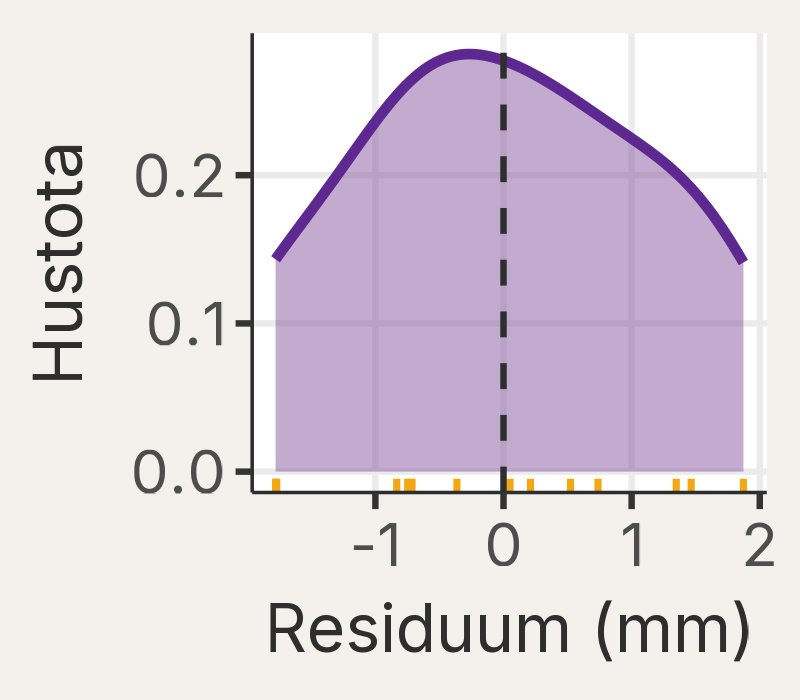

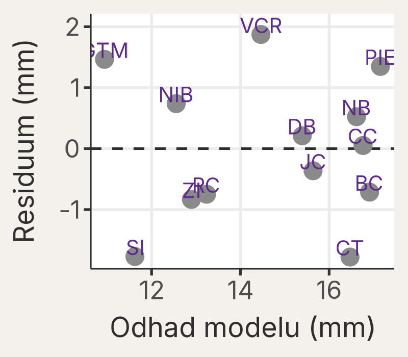

## Co z diagnostiky plyne?

Co vidíme

- kladná i záporná residua;
- žádný nápadný oblouk;
- žádný zřetelný trychtýř.

Co zůstává nejisté

- jen 13 bodů;
- rozdílná přesnost průměrů;
- možná prostorová podobnost lokalit;
- vliv několika jižních lokalit.

Kontrola není potvrzení dokonalosti

Grafy neukázaly zjevný problém. Nemohou však ověřit všechny předpoklady ani napravit omezení studie.

## Co znamená 0,490 mm na stupeň?

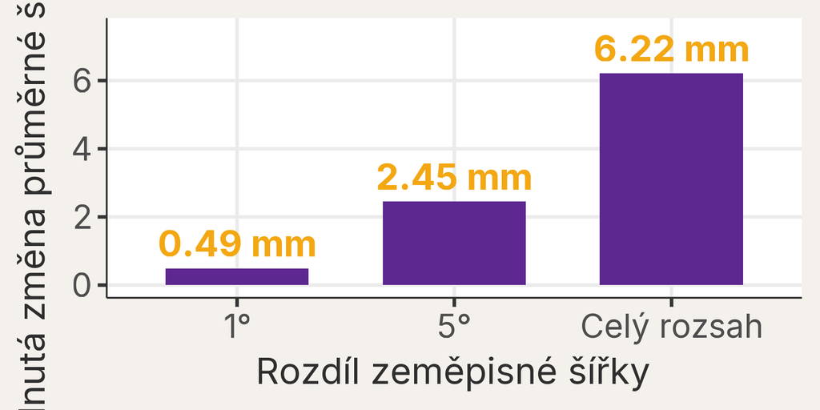

Které měřítko vám nejlépe říká, zda je efekt biologicky zajímavý? Jakou další biologickou informaci byste chtěli znát?

## Nejprve „o kolik?“, potom „jak jistě?“

Velikost efektu

- 0.49 mm na 1°;
- 2.45 mm na 5°;
- 6.22 mm přes sledovaný rozsah.

Biologický význam

Průměry lokalit se pohybují přibližně mezi **9.9 a 18.5 mm**.

Rozdíl přes pobřeží proto stojí za pozornost.

Pořadí důkazů

**Velikost efektu → biologický význam → nejistota → slučitelnost s přesnou nulou → omezení.**

## Z minulé lekce: odhad a nejistota

Odhad

Nejlepší bodový popis vztahu:

**0.49 mm/°**

Přesnost

Standardní chyba odhadu:

**0.0795 mm/°**

Odhad a standardní chyba odpovídají na dvě různé otázky. Jedno číslo nenahrazuje druhé.

## Jaké efekty ještě připouštějí data?

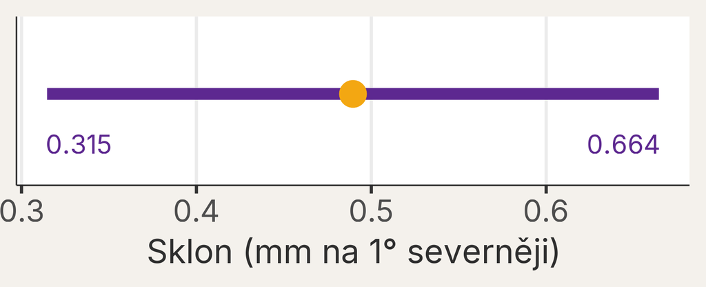

Přečtěte interval

Které malé i velké kladné efekty zůstávají slučitelné s daty a modelem? Obsahuje interval nulový sklon?

## Co kdyby systematický sklon byl nula?

Nulový svět, který budeme simulovat

- systematický populační sklon nastavíme na **0 mm/°**;
- ponecháme stejných 13 zeměpisných šířek;
- ke každé lokalitě přidáme nové náhodné residuum;
- velikost residuí odhadneme z diagnostikovaného krabího modelu.

Proč lokality nebudou stejné

Náhodná část zastupuje výběrovou variabilitu, nepřesnost měření, nepozorované místní podmínky a další biologické rozdíly.

Nula znamená žádný **systematický lineární trend**, nikoli žádnou variabilitu mezi lokalitami.

## Jak budou vypadat fitované sklony?

Když je vložený systematický sklon nula, budou všechny přímky přesně vodorovné?

**A)** Všechny sklony budou přesně 0.

**B)** Budou kolísat kolem 0.

**C)** Budou se shlukovat kolem 0,490.

Když nehlasujeme: vyberte A/B/C a doplňte „Sklon se změnil, protože se změnila …; stejné zůstalo …“

## Dvacet studií v nulovém světě

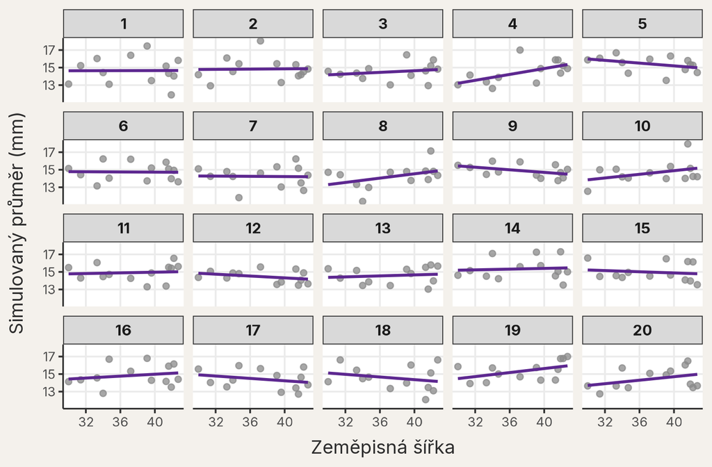

Stejné zůstaly zeměpisné šířky, nulový systematický sklon a velikost residuí. Změnila se nová náhodná residua.

## Nulový sklon neznamená nulový odhad

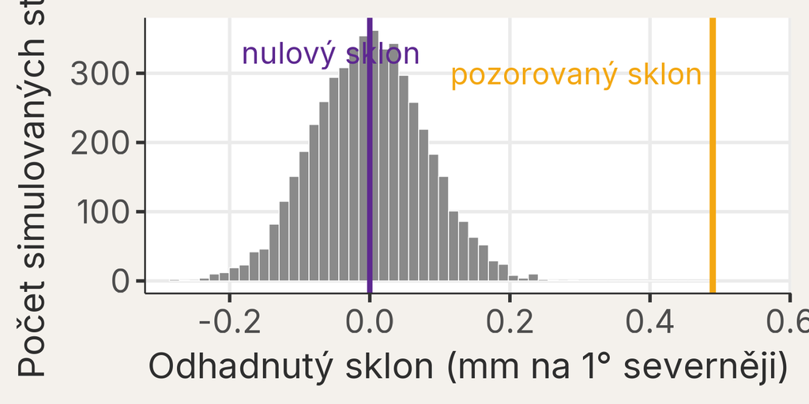

Nulová hypotéza říká, že systematický populační sklon je nula. Jednotlivé odhady kolem ní kolísají.

## Kolikrát se standardní chyba vejde do rozdílu?

| Krok | Hodnota |
| --- | --- |
| pozorovaný efekt | 0.490 mm/° |
| nulový efekt | 0 mm/° |
| rozdíl od nuly | 0.490 mm/° |
| standardní chyba | 0.0795 mm/° |

Spočítejte vzdálenost

Kolikrát se standardní chyba 0.0795 vejde do rozdílu 0.490?

## Pozorovaný sklon leží 6,16 SE od nuly

$$\frac{
0.490-0
}{
0.0795
}
=
6.16$$

Význam výsledku

Pozorovaný sklon je přibližně **6.16 standardních chyb od nulového sklonu**.

## Teprve teď zavedeme obecný zápis

$$t=
\frac{
\hat{\beta}-\beta_0
}{
\operatorname{SE}(\hat{\beta})
}$$

V našem příkladu

- $\hat{\beta}$ = pozorovaný sklon;
- $\beta_0$ = nulový sklon;
- $\operatorname{SE}$ = standardní chyba sklonu.

Co t není

t-statistika není velikost efektu ani biologická důležitost. Je to standardizovaná vzdálenost od jedné zvolené hodnoty.

## Stejné t, jiné množství informace

Je $|t|=2$ stejně neobvyklé u studie se 3 pozorováními a u studie s 10 002 pozorováními?

Potřebujeme vědět, kolik nezávislé informace zůstalo po odhadu modelu.

## Sudoku: kolik voleb ještě zbývá?

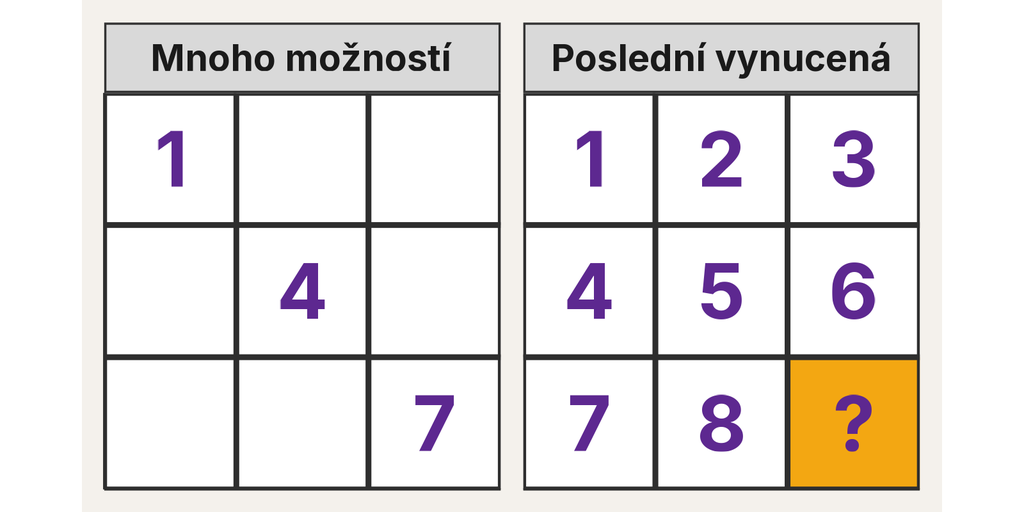

Sudoku ukazuje myšlenku „kolik volby zbývá pod omezeními“. **Není to výpočet statistických stupňů volnosti.**

## Čtyři čísla musí mít průměr 10

Požadovaný součet je $4 \times 10 = 40$.

$$7+12+x+y=40$$

Kolik voleb ještě zbývá?

Můžeme z jedné rovnice určit zároveň $x$ i $y$? Kterou hodnotu ještě smíme zvolit a která pak bude vynucená?

## Jakmile zvolíme třetí číslo, čtvrté je vynucené

$$7+12+9+x=40$$

$$x=40-7-12-9=12$$

Jedno omezení odebere jednu volbu

Pro čtyři čísla s pevným průměrem zbývají **$4-1=3$ stupně volnosti**.

## V regresi jsme odhadli dva koeficienty

Co vstoupilo do modelu

**13 průměrů slanisek**

$n=13$

Co model odhadl

**intercept + sklon**

$p=2$

$$df_{\mathrm{res}}=n-p=13-2=11$$

Residuální stupně volnosti = počet pozorování (zde lokalit) − počet odhadnutých koeficientů.

## Jak df mění t-křivku?

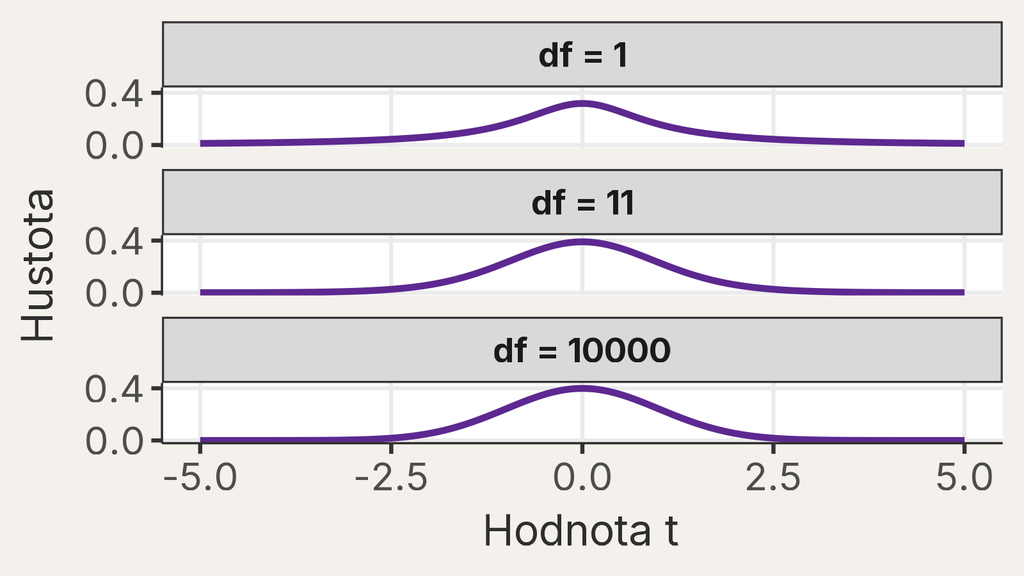

Která křivka ponechává nejvíce plochy daleko od nuly? Co se mění a co zůstává stejné?

## Jak čteme vybarvenou plochu?

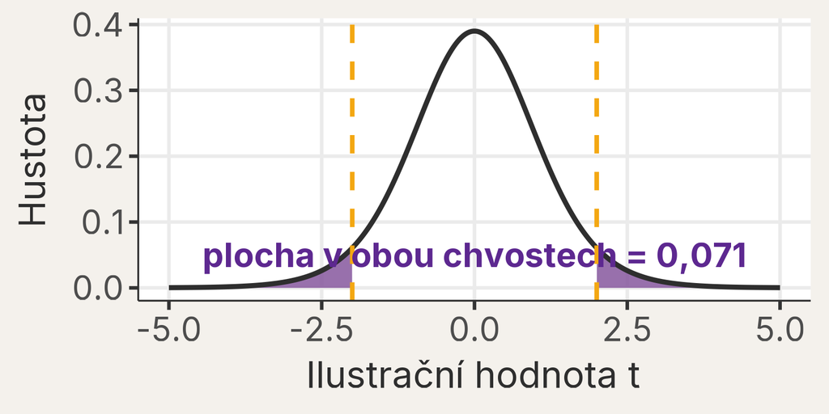

Pouze ilustrace — ještě ne krabí výsledek

Vybarvení ukazuje všechny hodnoty $t \leq -2$ a $t \geq 2$ při $df=11$. Celá plocha pod křivkou je 1.

## Krabí výsledek leží v obou malých chvostech

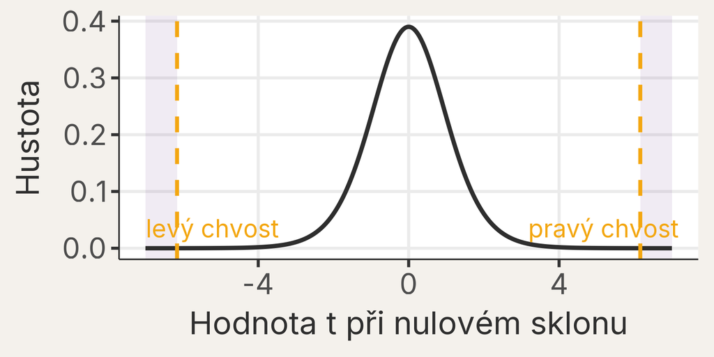

P-hodnota v jedné větě

Pokud by nulový sklon a předpoklady modelu platily, p-hodnota je pravděpodobnost t-statistiky alespoň tak vzdálené od nuly jako ta naše. Je to plocha, proto leží **od 0 do 1**.

## Která věta p-hodnotu čte správně?

**A)** Pravděpodobnost, že nulová hypotéza platí, je 0.000071.

**B)** Tak malá p-hodnota znamená obrovský biologický efekt.

**C)** Kdyby platil nulový sklon a model, takto krajní t by bylo velmi vzácné.

Když nehlasujeme: zapište A/B/C a podtrhněte část věty, která rozhodla.

## P-hodnota není stroj na pravdu

Nejblíže je C

Interpretace začíná podmínkou:

**„Kdyby platil nulový sklon a předpoklady modelu…“**

Škrtněte nesprávné výklady

- pravděpodobnost pravdy $H_0$;
- velikost efektu;
- pravděpodobnost „náhody“;
- šance úspěšné replikace;
- kontrola všech předpokladů.

Interpretace odpovídá zásadám [ASA Statement on Statistical Significance and P-Values](https://doi.org/10.1080/00031305.2016.1154108).

## Někdy musíme udělat rozhodnutí

Nulovou hypotézu **zamítneme**, nebo **nezamítneme**?

Jaké pravidlo potřebujeme?

Jak velké dlouhodobé riziko falešného zamítnutí pravdivé nulové hypotézy jsme ochotni přijmout?

Pravidlo musíme zvolit **před pohledem na výsledek**.

## Pětiprocentní hranice je častá, ne přírodní

Hladina významnosti

Předem zvolená hranice dlouhodobého rizika, že zamítneme nulovou hypotézu, i když platí.

Často volíme **$\alpha=0{,}05$**; přísnější analýza může zvolit například **$\alpha=0{,}01$**.

Pod zvolenou hranicí

Při **$p \leq \alpha$** nulovou hypotézu zamítneme.

Výsledek je **statisticky významný** neboli **statisticky signifikantní**.

Nad zvolenou hranicí

Při **$p > \alpha$** nulovou hypotézu nezamítneme.

To není důkaz přesně nulového efektu.

## Kritické hodnoty: historická zkratka

Co se hledalo v tabulce

- t-rozdělení;
- oboustranné $\alpha=0{,}05$;
- $df=11$;
- kritická hranice $|t|=2.201$.

Krabí výsledek

$|t|=6.159$

Pozorovaný výsledek leží daleko za kritickou hranicí.

Tištěná tabulka, `qt()`, `pt()` a p-hodnota v `summary()` představují různé cesty ke stejnému rozhodovacímu pravidlu.

## Výsledek v R

```r
coef(summary(mod_krabi))[
  "zemepisna_sirka",
]
```

```
    Estimate   Std. Error      t value     Pr(>|t|)
4.895308e-01 7.947738e-02 6.159372e+00 7.112446e-05
```

```r
df.residual(mod_krabi)
```

```
[1] 11
```

Řádek biologické otázky

`zemepisna_sirka`

Tři místa

- `t value` = **6.159**;
- `Pr(>|t|)` = **0.000071**;
- residual df = **11**.

## Stejnou otázku položíme intervalu

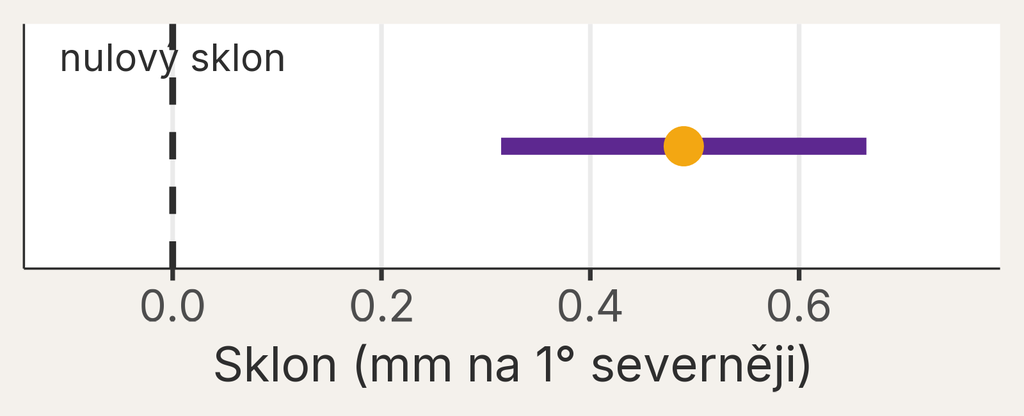

Dvě cesty, stejné rozhodnutí při 5% hladině

95% interval **[0.315; 0.664] mm/°** neobsahuje nulu. Navíc ukazuje, jaké velikosti efektu zůstávají slučitelné s daty a modelem.

## Dvě absurdní situace jako paměťová pomůcka

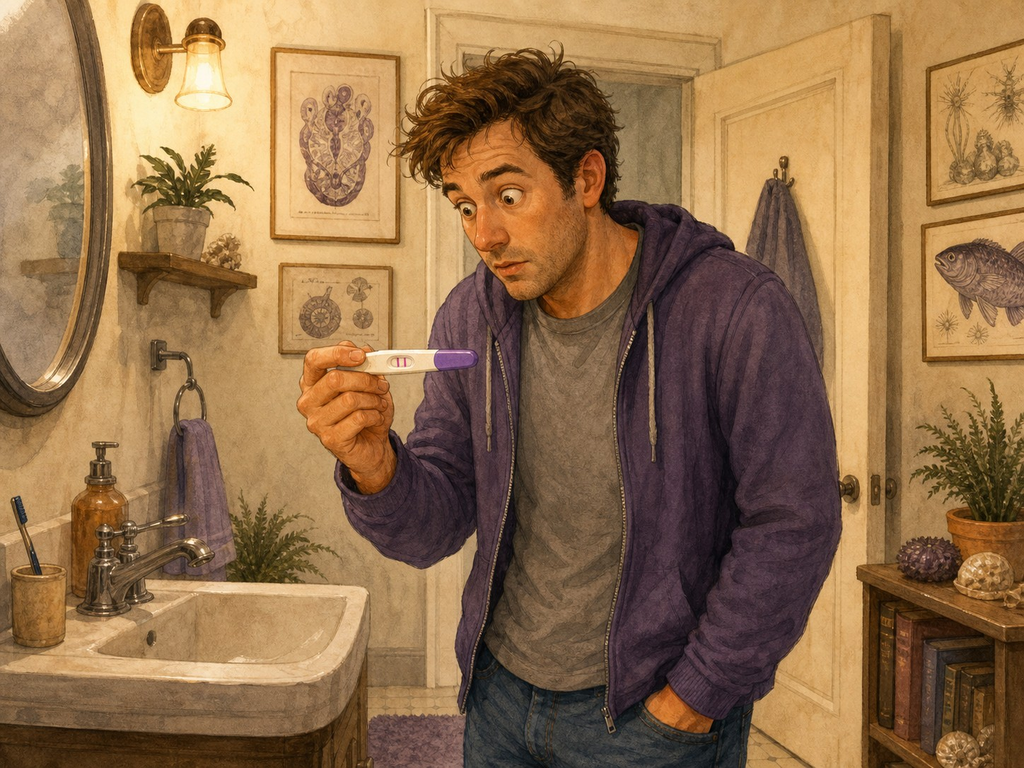

**Falešně pozitivní:** test hlásí stav, který není přítomen.

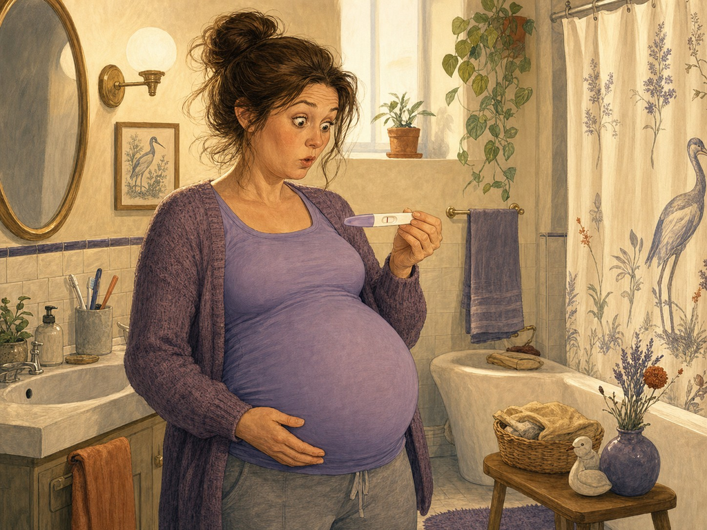

**Falešně negativní:** test přehlédne stav, který přítomen je.

Jen mnemotechnická zkratka; definice vždy závisí na zvoleném nulovém stavu.

## Invazní druh: která chyba je která?

$$H_0:\ \text{invazní druh v oblasti není přítomen}$$

| Skutečnost | Průzkum: „nepřítomen“ | Průzkum: „přítomen“ |
| --- | --- | --- |
| druh není přítomen | správné rozhodnutí | **A: zbytečný zásah** |
| druh je přítomen | **B: přehlédnutá invaze** | správné rozhodnutí |

Zařaďte A a B

Která je chyba I. druhu a která chyba II. druhu? Která může být závažnější a na čem odpověď závisí?

## Stejná dvojice chyb u krabů

Chyba I. druhu

Zamítneme nulový sklon, přestože je v populaci opravdu nulový.

**Falešný poplach.** Dlouhodobé riziko řídí $\alpha$.

Chyba II. druhu

Nulový sklon nezamítneme, přestože v populaci existuje biologicky důležitý vztah.

**Přehlédnutý efekt.**

Rozhodnutí není jistota. Závažnost chyby určuje biologický a praktický kontext.

## Jak dobře studie odhalí vztah, který existuje?

Síla testu

Schopnost studie a rozhodovacího postupu odhalit **předem zvolený biologicky smysluplný efekt**, který skutečně existuje.

Než odhalíme směry

Co podle vás zvýší sílu: větší efekt, více lokalit, nebo menší residuální variabilita?

- větší skutečný efekt se odhaluje snáze;
- více nezávislých lokalit obvykle zvyšuje sílu;
- menší residuální variabilita zvyšuje přesnost a sílu;
- méně přísná $\alpha$ zvyšuje sílu za cenu více chyb I. druhu.

Co síla není

Není to pravděpodobnost, že je naše hypotéza nebo závěr pravdivý.

## Dva konkrétní scénáře síly

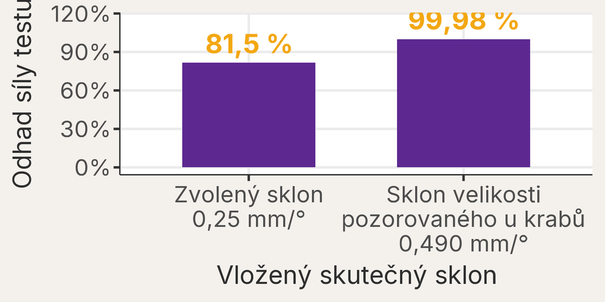

Co zůstalo v simulaci pevné

13 zeměpisných šířek · residuální SD 1.23 mm · $\alpha=0{,}05$ · stejný lineární model · 5 000 opakování.

Vysvětlete rozdíl **81,5 %** a **99,98 %** jednou větou. Které pevné podmínky musíme spolu s číslem uvést?

## „p < 0,05, proto je hypotéza pravdivá“

Co je na této větě špatně?

Co ve větě chybí

Velikost efektu, jednotky, biologický význam, interval a omezení.

Co věta tvrdí neprávem

P-hodnota nedává pravděpodobnost pravdy a test hypotézu nedokazuje.

## Napište výsledek pro biologa

Pět až šest vět

Začněte tím, **co se mění a o kolik**. Potom přidejte biologický význam, nejistotu, přesnou nulu a omezení.

Důkazy, které máte k dispozici

- 13 slanisek;
- 0.49 mm/°; 2.45 mm/5°;
- 6.22 mm přes sledovaný rozsah;
- 95% CI [0.315; 0.664] mm/°;
- $t=6.16$, $df=11$, $p=0.000071$;
- observační data, agregace po lokalitách, jednoduchý model.

Vyměňte si větu se sousedem: začíná efektem a končí omezením, nebo p-hodnotou?

## Jedna možná odpověď v pořadí důkazů

Úplný výsledek v pořadí důkazů

Na 13 sledovaných slaniskách se průměrná šířka krunýře samců zvyšovala přibližně o **0.49 mm na každý stupeň**, tedy asi o **2.45 mm na 5°**. Přes celý sledovaný rozsah odpovídá přímka změně asi **6.22 mm**, která je vzhledem k velikosti krabů biologicky zajímavá. 95% interval spolehlivosti sahal od **0.315 do 0.664 mm/°**. Při $\alpha=0{,}05$ byl výsledek statisticky významný; za předpokladů modelu byla data obtížně slučitelná s přesně nulovým sklonem ($t\approx6.16$, $df=11$, $p\approx0.000071$). Výsledek podporuje kladný vztah na sledovaných slaniskách, ale sám neprokazuje příčinu ani obecnou platnost vztahu mimo ně.

## Co se do jedné přímky nevešlo

- průměry lokalit nemají úplně stejnou přesnost;
- zprůměrováním jsme skryli rozdíly mezi jednotlivými kraby;
- dvě nejjižnější lokality mají poměrně velký vliv;
- geograficky blízká slaniska nemusí být nezávislá;
- observační vztah neprokazuje příčinný mechanismus.

Opatrný závěr není slabý závěr

Uvede, co data podporují, i podmínky, za kterých to tvrdíme.

## Měsíc pořád není ze sýra

P-hodnota neříká pravděpodobnost, že je Měsíc ze sýra.

Hlavní myšlenka

Věda nezískává pravdu z $p<0{,}05$. Staví opatrné a opravitelné závěry z **velikosti efektu, biologického významu, nejistoty, kvality studie a souvislostí**.

## Následující lekce: místo sklonu rozdíl skupin

Dnes

Číselný prediktor: zeměpisná šířka.

Hlavní efekt: **sklon** v mm/°.

Příště

Kategoriální prediktor: například kontrola a zásah.

Hlavní efekt: **rozdíl mezi skupinami**.

Pořadí důkazů zůstane stejné: velikost rozdílu → biologický význam → nejistota → přesná nula → omezení.

## Co si odnést

- Testovatelnost není totéž jako věrohodnost nebo pravda.
- Regresní koeficient je hlavní velikost efektu; vždy jej čteme v jednotkách a biologickém kontextu.
- Standardní chyba a interval ukazují nejistotu; t, df a p podmíněně hodnotí slučitelnost s přesnou nulou.
- Rozhodnutí podle $\alpha$ může vést k chybě I. nebo II. druhu; síla popisuje schopnost odhalit zvolený existující efekt.
- Dobrá závěrečná věta začíná efektem a končí předpoklady a omezeními, ne p-hodnotou.

## Jaký důkaz by změnil váš závěr?

Která část důkazů o krabech je nejsilnější — a jaká nová data nebo porušení předpokladů by vás přiměla závěr upravit?

Vědecký závěr je silný tehdy, když je přesný **a zároveň otevřený revizi**.